# 民法之解釋與適用

董宸賓  
2023-10-15

### 法源適用順序

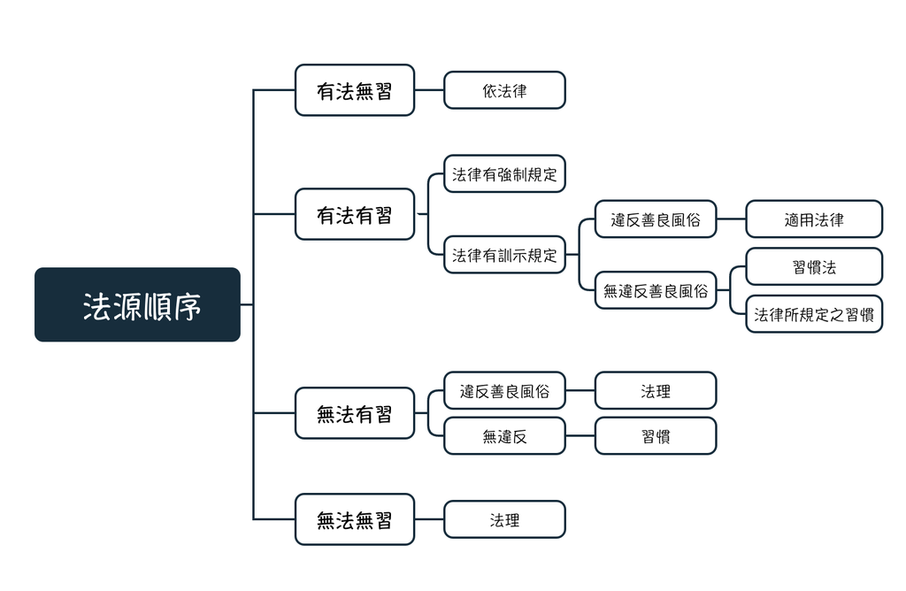

### [民法1、2](https://law.moj.gov.tw/LawClass/LawAll.aspx?pcode=B0000001)

> 第一條：民事，法律所未規定者，依習慣；無習慣者，依法理。  
> 第二條：民事所適用之習慣，以不背於公共秩序或善良風俗者為限。

## 法源

### 1.定義

- 限縮：廣義上之法律
- 廣義：判決之基礎->法律＋契約(相對人中的法律)

## 2.廣義之法律

### 1 民法及民事特別法

### 2 行政法規

- [民71](https://law.moj.gov.tw/LawClass/LawSingle.aspx?pcode=B0000001&flno=71)：公法與私法之過度法律

  > 法律行為，違反強制或禁止之規定者，無效。但其規定並不以之為無效者，不在此限。
- 行政法影響民法規定：[道交安全條例15](https://law.moj.gov.tw/LawClass/LawSingle.aspx?pcode=K0040013&flno=15)

  > 汽車新領牌照應申請登記。

  民法之不動產無需登記

### 3 憲法：不得直接援引

- [民72](https://law.moj.gov.tw/LawClass/LawSingle.aspx?pcode=B0000001&flno=72)等過渡性法條

  > 法律行為，有背於公共秩序或善良風俗者，無效。
- 做合憲性解釋

### 4 國際法與自治法

### 5 法律所規定之習慣

- 非指民法上之習慣，而是在法條裡有特別提及：[民法207](https://law.moj.gov.tw/LawClass/LawSingle.aspx?pcode=B0000001&flno=207)

  > 利息不得滾入原本再生利息。但當事人以書面約定，利息遲付逾一年後，經催告而不償還時，債權人得將遲付之利息滾入原本者，依其約定。  
  > 前項規定，如商業上另有習慣者，不適用之。

## 3 習慣法

### 1 習慣法四要件

1. 多年慣行之事實  
   2. 普通一般人之確信心  
   3. 不違背善量風俗(民2)  
   4. 通常有判決加以承認

17年上字第613(已廢止)

> 習慣法之成立，須以多年慣行之事實及普通一般人之確信心為其基礎。

## 4 法理

### 一般法律的原則

- 公共利益、權利濫用、誠實信用
- 平等原則、舉輕明重、舉重明輕

### 新定之法律、制定中的法律、外國之法律

### 判例與決議

- 決議：最高法院及最高行政法院召開會議的方式來研討法律問題而作成的結果。

行政法院組織法第16條第3項（已廢止），目前不會再有任何決議，但可作為裁判參考

> 最高行政法院之裁判，其所持之法律見解，各庭間見解不一致者，於依第一項規定編為判例之前，應舉行院長、庭長、法官聯席會議，以決議統一其法律見解。
- 判例：最高法院、最高行政法院透過決議將指標性的裁判編撰而成，交給其他法院參考

[法院組織法第57條之1](https://law.moj.gov.tw/LawClass/LawSingle.aspx?pcode=A0010053&flno=57-1)

> I 最高法院於中華⺠國一百零七年十二月七日本法修正施行前依法選編之判例，若無裁判全文可資查考者 ，應停止適用。  
> II 未經前項規定停止適用之判例，其效力與未經選編為判例之最高法院裁判相同。

### 判決與判例有何問題

- 判決與法例並無所謂強制之效力，但因為其為最高法院所製成，下級法官會遵循其之規定。
- 又依司法院釋字第374號解釋，判決與決議都可以如命令性質向大法官申請違憲審查，使其近乎有命令之地位。

如此延伸出兩種問題：

- 將本質為抽象性的法規， 視為一般的抽象法規範來適用，將產生個案是否適用之疑異。
- 因決議與判例皆為最高法院僅透過決議而製成，又其被視為一般的抽象法規範來適用，恐有逾越司法權之虞。

## 私法關係基本結構

### 關係結構

- 意義：由民事法行成、規範並能藉由其實現
- 內容：權利之得喪變更，至少一個權利為要素
- 變動：基本由當事人自由約定，例外加以限制。

[output not shown]

- 財產權之特性：得轉移、繼承，又稱一生專屬性
- 對世性之特性：得以向第三主張權利內容。

## 法律適用的意義

為何民法之適用有如此多的層級？其係因為民事法庭不得以無法律無明文規定而拒絕審判。與此延伸出法官造法之概念